# Coursera Shiny Project

31 March 2019

## Overview

For the main application please visit https://elenay.shinyapps.io/MyShinyProject/.

- The application uses *mtcars* dataset The data was extracted from the 1974 Motor Trend US magazine, and comprises fuel consumption and 10 aspects of automobile design and performance for 32 automobiles (1973-74 models).
- The interactive shiny application allows exploring the relationship between the weight of the vehicle and miles per gallon.
- The user can choose to visualise only subset of results selecting the range of vehicle weight

## Web Application - user instructions

The developed shiny application visualize the relationship between the car weight and miles per gallon for selected car brands with different number of cylinders. The application enables users

- to select the range of car weight and re-plotting the chart using the range slider
- to select a subset of cars with specific number of cylinders (4, 6 or 8) using the input boxes and investigate how the relationship between car weight and mpg changes by the number of cylinders.
- the results are visualised as a scatter plot with each data point clearly labelle with car brand name.

## Dataset Summary

Car brands analyzed

```
 [1] "Mazda RX4"           "Mazda RX4 Wag"       "Datsun 710"
 [4] "Hornet 4 Drive"      "Hornet Sportabout"   "Valiant"
 [7] "Duster 360"          "Merc 240D"           "Merc 230"
[10] "Merc 280"            "Merc 280C"           "Merc 450SE"
[13] "Merc 450SL"          "Merc 450SLC"         "Cadillac Fleetwood"
[16] "Lincoln Continental" "Chrysler Imperial"   "Fiat 128"
[19] "Honda Civic"         "Toyota Corolla"      "Toyota Corona"
[22] "Dodge Challenger"    "AMC Javelin"         "Camaro Z28"
[25] "Pontiac Firebird"    "Fiat X1-9"           "Porsche 914-2"
[28] "Lotus Europa"        "Ford Pantera L"      "Ferrari Dino"
[31] "Maserati Bora"       "Volvo 142E"
```

mpg - miles per gallon, wt - weight, cyl - cylinders

```
'data.frame':   32 obs. of  3 variables:
 $ mpg: num  21 21 22.8 21.4 18.7 18.1 14.3 24.4 22.8 19.2 ...
 $ wt : num  2.62 2.88 2.32 3.21 3.44 ...
 $ cyl: num  6 6 4 6 8 6 8 4 4 6 ...
```

wt:

```
   Min. 1st Qu.  Median    Mean 3rd Qu.    Max.
  1.513   2.581   3.325   3.217   3.610   5.424
```

cyl:

```
   Min. 1st Qu.  Median    Mean 3rd Qu.    Max.
  4.000   4.000   6.000   6.188   8.000   8.000
```

## Car Weight vs Miles per Gallon by the Number of Cylinders

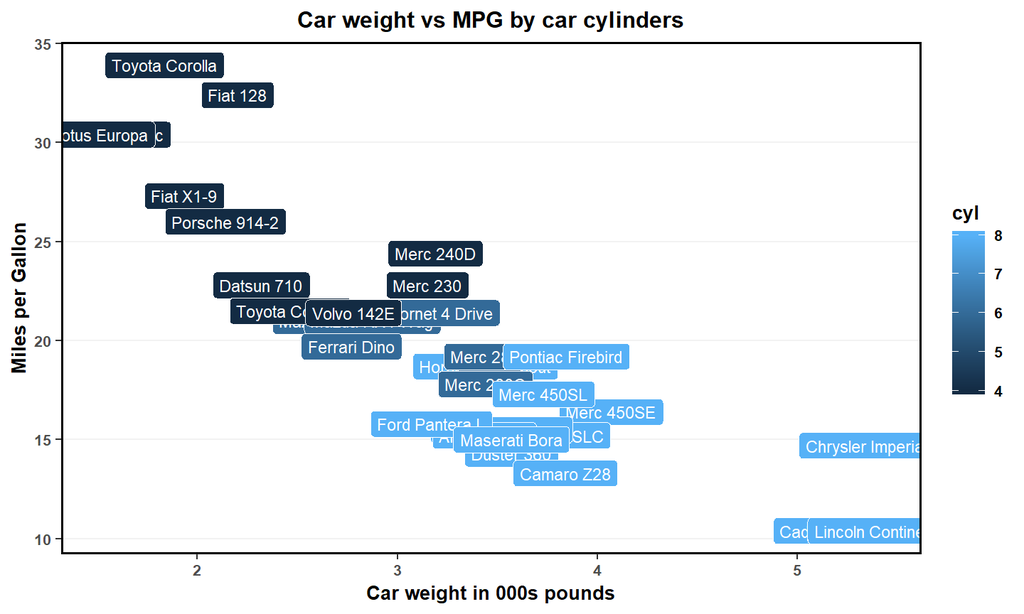